# Welcoming new learners to data science with the tidyverse

welcoming learners

to data science

with the tidyverse

mine çetinkaya-rundel  
duke university + posit

bit.ly/tidyperspective-dds

[@minebocek](https://twitter.com/minebocek)

# introduction

## setting the scene

### about me

[figure not shown]

**Focus:**

Data science for new learners

[figure not shown]

**Philosophy:**

Let them eat cake (first)!

### about data science education

[figure not shown]

**Assumption 1:**

Teach authentic tools

[figure not shown]

**Assumption 2:**

Teach R as the authentic tool

## takeaway

> The tidyverse provides an effective and efficient pathway for undergraduate students at all levels and majors to gain computational skills and thinking needed throughout the data science cycle.

Çetinkaya-Rundel, M., Hardin, J., Baumer, B., McNamara, A., Horton, N., & Rundel, C. (2022). An educator’s perspective of the tidyverse. Technology Innovations in Statistics Education, 14(1). dx.doi.org/10.5070/T514154352.

## and that pathway starts with…

Introduction to Data Science

[sta199-f22-1.github.io](https://sta199-f22-1.github.io/)

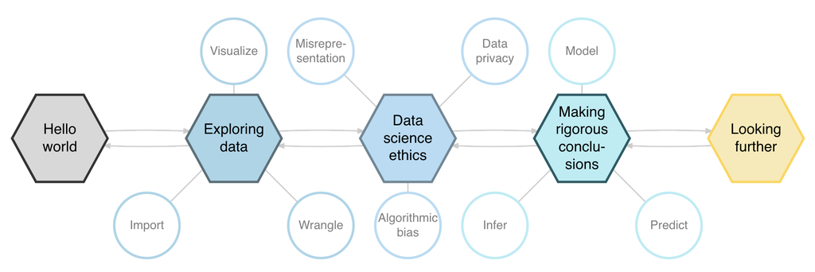

# principles of the tidyverse

## tidyverse

```r
library(tidyverse)
```

[figure not shown]

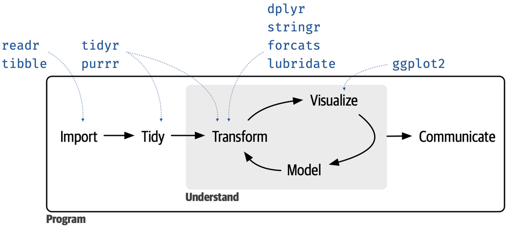

Wickham et al., (2019). Welcome to the Tidyverse. Journal of Open Source Software, 4(43), 1686, doi.org/10.21105/joss.01686.

## examples: two “simple” tasks

### grouped summary statistics:

Based on the applicants’ home ownership status, compute the average loan amount and the number of applicants. Display the results in descending order of average loan amount.

| Homeownership | Average loan amount | Number of applicants |
| --- | --- | --- |
| Mortgage | $18,132 | 4,778 |
| Own | $15,665 | 1,350 |
| Rent | $14,396 | 3,848 |

### multivariable data visualizations:

Create side-by-side box plots that show the relationship between loan amount and application type based on homeownership.

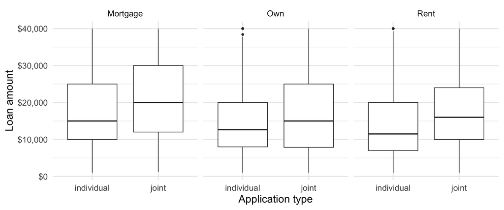

# teaching with the tidyverse

## task 1 - step 1

Based on the applicants’ home ownership status, compute the average loan amount and the number of applicants. Display the results in descending order of average loan amount.

```r
loans
```

```
# A tibble: 9,976 × 3
  loan_amount homeownership application_type
        <int> <chr>         <fct>
1       28000 Mortgage      individual
2        5000 Rent          individual
3        2000 Rent          individual
4       21600 Rent          individual
5       23000 Rent          joint
6        5000 Own           individual
# … with 9,970 more rows
```

## task 1 - step 2

Based on the applicants’ home ownership status, compute the average loan amount and the number of applicants. Display the results in descending order of average loan amount.

```r
loans |>
  group_by(homeownership)
```

```
# A tibble: 9,976 × 3
# Groups:   homeownership [3]
  loan_amount homeownership application_type
        <int> <chr>         <fct>
1       28000 Mortgage      individual
2        5000 Rent          individual
3        2000 Rent          individual
4       21600 Rent          individual
5       23000 Rent          joint
6        5000 Own           individual
# … with 9,970 more rows
```

## task 1 - step 3

Based on the applicants’ home ownership status, compute the average loan amount and the number of applicants. Display the results in descending order of average loan amount.

```r
loans |>
  group_by(homeownership) |>
  summarize(
    avg_loan_amount = mean(loan_amount)
    )
```

```
# A tibble: 3 × 2
  homeownership avg_loan_amount
  <chr>                   <dbl>
1 Mortgage               18132.
2 Own                    15665.
3 Rent                   14396.
```

## task 1 - step 4

Based on the applicants’ home ownership status, compute the average loan amount and the number of applicants. Display the results in descending order of average loan amount.

```r
loans |>
  group_by(homeownership) |>
  summarize(
    avg_loan_amount = mean(loan_amount),
    n_applicants = n()
    )
```

```
# A tibble: 3 × 3
  homeownership avg_loan_amount n_applicants
  <chr>                   <dbl>        <int>
1 Mortgage               18132.         4778
2 Own                    15665.         1350
3 Rent                   14396.         3848
```

## task 1 - step 5

Based on the applicants’ home ownership status, compute the average loan amount and the number of applicants. Display the results in descending order of average loan amount.

```r
loans |>
  group_by(homeownership) |>
  summarize(
    avg_loan_amount = mean(loan_amount),
    n_applicants = n()
    ) |>
  arrange(desc(avg_loan_amount))
```

```
# A tibble: 3 × 3
  homeownership avg_loan_amount n_applicants
  <chr>                   <dbl>        <int>
1 Mortgage               18132.         4778
2 Own                    15665.         1350
3 Rent                   14396.         3848
```

## task 1 with the tidyverse

**[input]** data frame

```r
loans |>
  group_by(homeownership) |>
  summarize(
    avg_loan_amount = mean(loan_amount),
    n_applicants = n()
    ) |>
  arrange(desc(avg_loan_amount))
```

```
# A tibble: 3 × 3
  homeownership avg_loan_amount n_applicants
  <chr>                   <dbl>        <int>
1 Mortgage               18132.         4778
2 Own                    15665.         1350
3 Rent                   14396.         3848
```

**[output]** data frame

- always start with a data frame and end with a data frame
- variables are always accessed from within data frames
- more verbose (than some other approaches), but also more expressive and extensible

## task 1 with `aggregate()`

```r
ns <- aggregate(
  loan_amount ~ homeownership,
  data = loans, FUN = length
  )
names(ns)[2] <- "n_applicants"

avgs <- aggregate(
  loan_amount ~ homeownership,
  data = loans, FUN = mean
  )
names(avgs)[2] <- "avg_loan_amount"

result <- merge(ns, avgs)
result[order(result$avg_loan_amount,
             decreasing = TRUE), ]
```

```
  homeownership n_applicants avg_loan_amount
1      Mortgage         4778        18132.45
2           Own         1350        15665.44
3          Rent         3848        14396.44
```

## task 1 with `aggregate()`

```r
ns <- aggregate(
  loan_amount ~ homeownership,
  data = loans, FUN = length
  )
names(ns)[2] <- "n_applicants"

avgs <- aggregate(
  loan_amount ~ homeownership,
  data = loans, FUN = mean
  )
names(avgs)[2] <- "avg_loan_amount"

result <- merge(ns, avgs)
result[order(result$avg_loan_amount,
             decreasing = TRUE), ]
```

```
  homeownership n_applicants avg_loan_amount
1      Mortgage         4778        18132.45
2           Own         1350        15665.44
3          Rent         3848        14396.44
```

**challenges:** need to introduce

- formula syntax
- passing functions as arguments
- merging datasets
- square bracket notation for accessing rows

## task 1 with `tapply()`

```r
sort(
  tapply(loans$loan_amount,
         loans$homeownership,
         mean),
  decreasing = TRUE
  )
```

```
Mortgage      Own     Rent
18132.45 15665.44 14396.44
```

## task 1 with `tapply()`

```r
sort(
  tapply(loans$loan_amount,
         loans$homeownership,
         mean),
  decreasing = TRUE
  )
```

```
Mortgage      Own     Rent
18132.45 15665.44 14396.44
```

**challenges:** need to introduce

- passing functions as arguments
- distinguishing between the various `apply()` functions
- ending up with a new data structure (`array`)
- reading nested functions

## task 2 - step 1

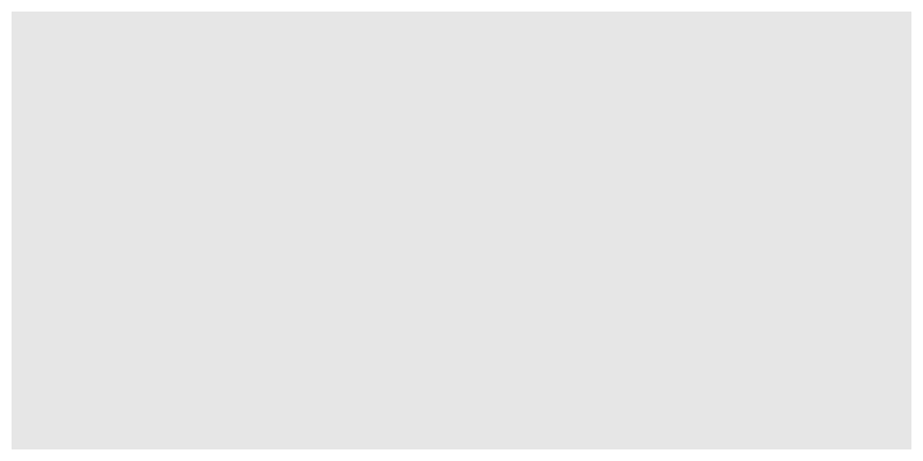

```r
ggplot(loans)
```

## task 2 - step 2

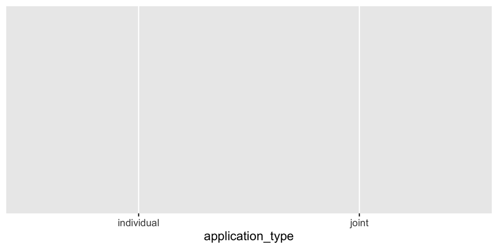

```r
ggplot(loans,
       aes(x = application_type))
```

## task 2 - step 3

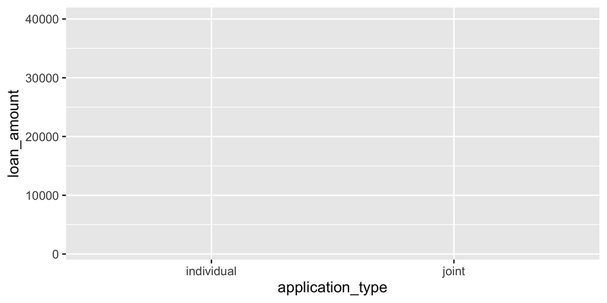

```r
ggplot(loans,
       aes(x = application_type,
           y = loan_amount))
```

## task 2 - step 4

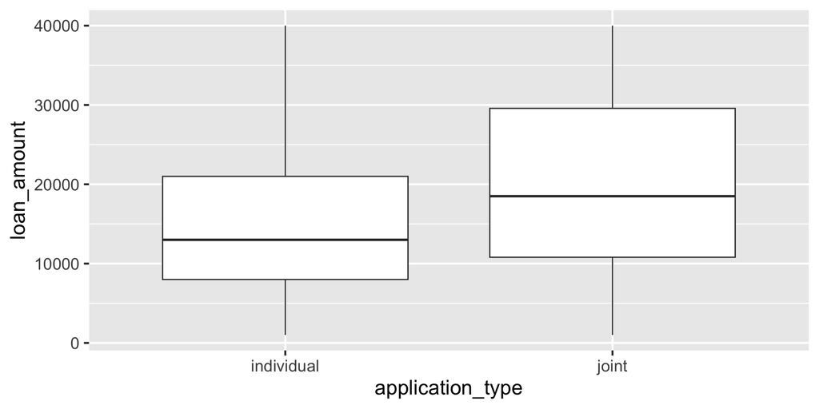

```r
ggplot(loans,
       aes(x = application_type,
           y = loan_amount)) +
  geom_boxplot()
```

## task 2 - step 5

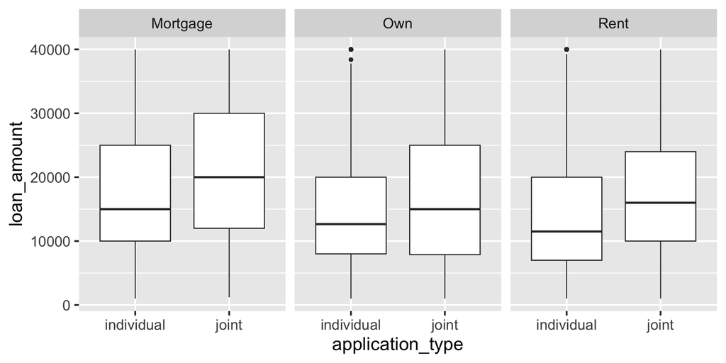

```r
ggplot(loans,
       aes(x = application_type,
           y = loan_amount)) +
  geom_boxplot() +
  facet_wrap(~ homeownership)
```

## task 2 with `boxplot()`

```r
levels <- sort(unique(loans$homeownership))

loans1 <- loans[loans$homeownership == levels[1],]
loans2 <- loans[loans$homeownership == levels[2],]
loans3 <- loans[loans$homeownership == levels[3],]

par(mfrow = c(1, 3))

boxplot(loan_amount ~ application_type,
        data = loans1, main = levels[1])
boxplot(loan_amount ~ application_type,
        data = loans2, main = levels[2])
boxplot(loan_amount ~ application_type,
        data = loans3, main = levels[3])
```

## task 2 with `boxplot()`

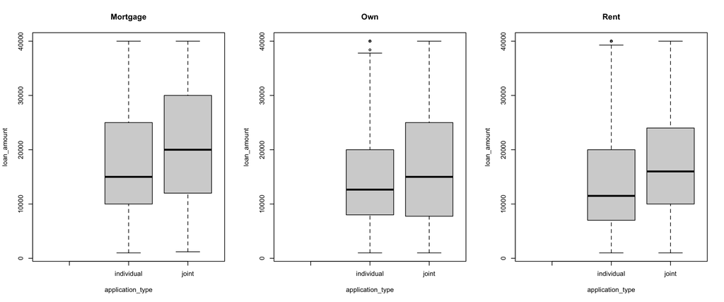

## we could keep going, but…

## tools designed for specific tasks vs. general tools

[figure not shown]

# final thoughts

## pedagogical strengths of the tidyverse

| Concept | Description |
| --- | --- |
| Consistency | Syntax, function interfaces, argument names, and orders follow patterns |
| Mixability | Ability to use base R and other functions within the tidyverse |
| Scalability | Unified approach to data wrangling and visualization works for datasets of a wide range of types and sizes |
| User-centered design | Function interfaces designed and improved with users in mind |
| Readability | Interfaces that are designed to produce readable code |
| Community | Large, active, welcoming community of users and resources |
| Transfarability | Data manipulation verbs inherit from SQL’s query syntax |

## keeping up with the tidyverse

- Blog posts highlight updates, along with the reasoning behind them and worked examples
- [Lifecycle stages](https://lifecycle.r-lib.org/articles/stages.html) and badges

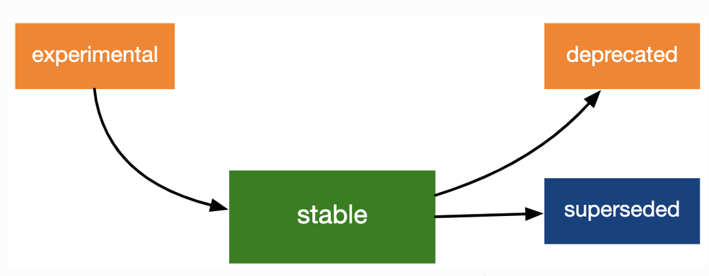

## building a curriculum

- Start with `library(tidyverse)`
- Teach by learning goals, not packages

## the curriculum we’ve built @ duke statsci

- **STA 199: Introduction to Data Science**
- courses:
  - STA 198: Introduction to Global Health Data Science
  - STA 210: Regression Analysis
  - STA 323: Statistical Computing
  - STA 440: Case Studies
- programs:
  - Inter-departmental major in Data Science (with CS)
  - Data Science concentration for the StatSci major
- and more…

## learn / teach the tidyverse

**learn** the tidyverse

tidyverse.org

[figure not shown]

**teach** the tidyverse

datasciencebox.org

[figure not shown]

## further reading

`+` collaborators

- Johanna Hardin, Pomona College
- Benjamin S. Baumer, Smith College
- Amelia McNamara, University of St Thomas
- Nicholas J. Horton, Amherst College
- Colin W. Rundel, Duke University

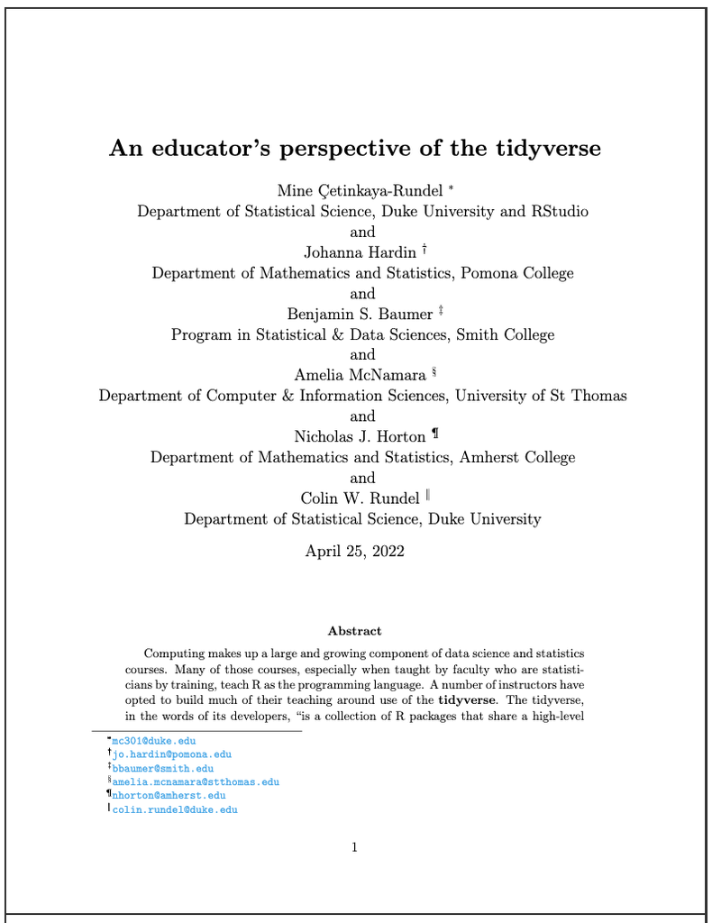

Çetinkaya-Rundel, M., Hardin, J., Baumer, B. S., McNamara, A., Horton, N. J., & Rundel, C. (2022). An educator’s perspective of the tidyverse. Technology Innovations in Statistics Education, 14(1). doi.org/10.5070/T514154352.

# thank you!

bit.ly/tidyperspective-dds